# Winter 2017 Cohort

The following information and diagrams were compiled from the NICHE Year 1 Implementation Survey. The data represent responses submitted by NICHE Coordinators in the same Leadership Training Program (LTP) Cohort. Individual responses have been de-identified to maintain anonymity.

## NICHE Program Leaders

Ninety two percent of the NICHE Coordinators of this LTP Cohort are female and 8 percent are male. On average, the NICHE Coordinators are 50 years of age and graduated between 1974 and 2010 with a Baccalaureate Degree as their first nursing degree. Eight percent have earned a master’s degree. Eight percent of the NICHE Coordinators are certified by the American Nurses Credentialing Center (ANCC) in gerontology and eight percent served as Geriatric Resource Nurses prior to becoming a NICHE Coordinator. Seventeen percent are Advanced Practice Nurses with most prepared as a Clinical Nurse Specialist (CNS) — Gerontological Focus. Forty two percent hold specialty certifications for Registered Nurses. The most common certifications held by the NICHE Coordinators of this cohort are: 1) Critical Care Nursing; 2) Critical Care Nursing,Nurse Executive—Advanced; and 3) Medical-Surgical Nursing. Eighty three percent are members of hospital-wide committees responsible for clinical practice and policy development and eighty three percent are members of hospital-wide committees responsible for improving the quality of care for older adults.

The following diagram illustrates clinical leadership roles the NICHE Coordinators have previously held at their respective organizations.

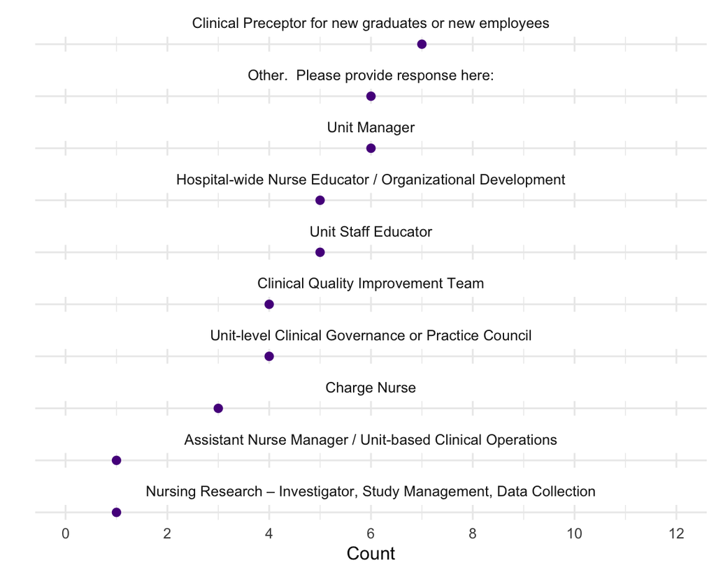

The following diagram illustrates the percent of time NICHE Coordinators devote to clinical practice responsibilities.

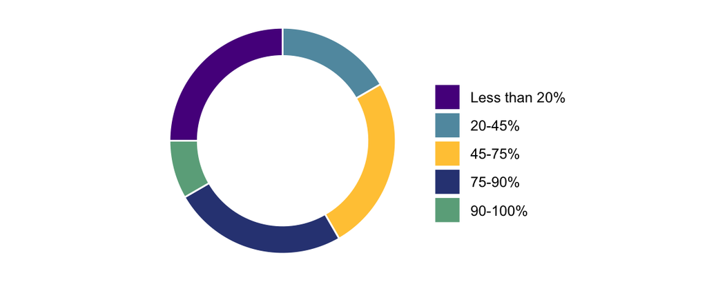

The following diagram illustrates the average number of hours per week NICHE Coordinators spend leading and managing the NICHE program at their respective organizations.

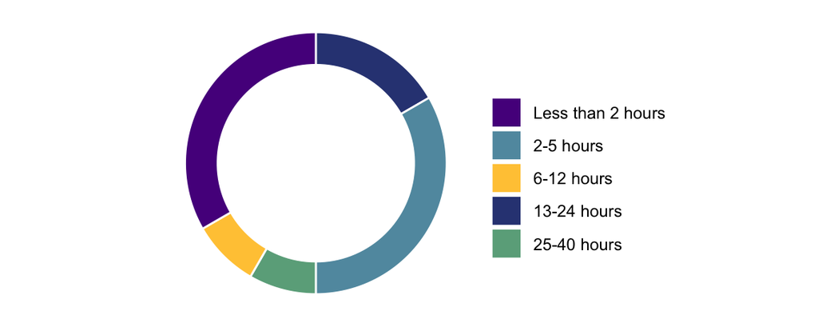

The following diagram identifies the different health care professionals that are members of the NICHE Program Steering Committee at organizations in this LTP Cohort.

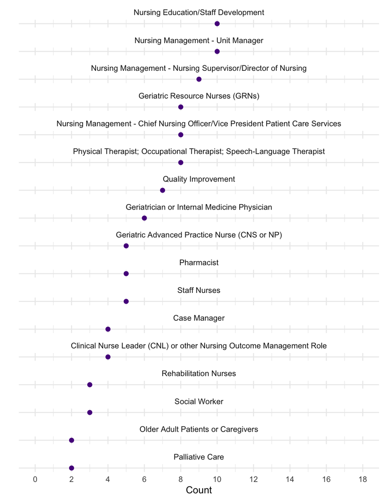

## Geriatric Resource Nurse Program

The following diagram illustrates criteria used to select the nursing units that pilot the Geriatric Resource Nurse (GRN) model at the organizations in this LTP Cohort.

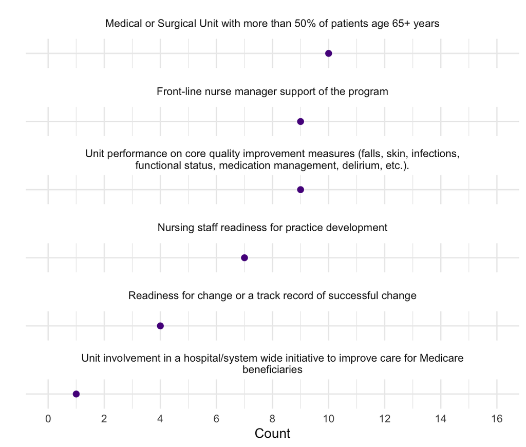

The following diagram illustrates the teaching methods used at the organizations in this LTP Cohort to deliver NICHE courses to front line nursing and support staff.

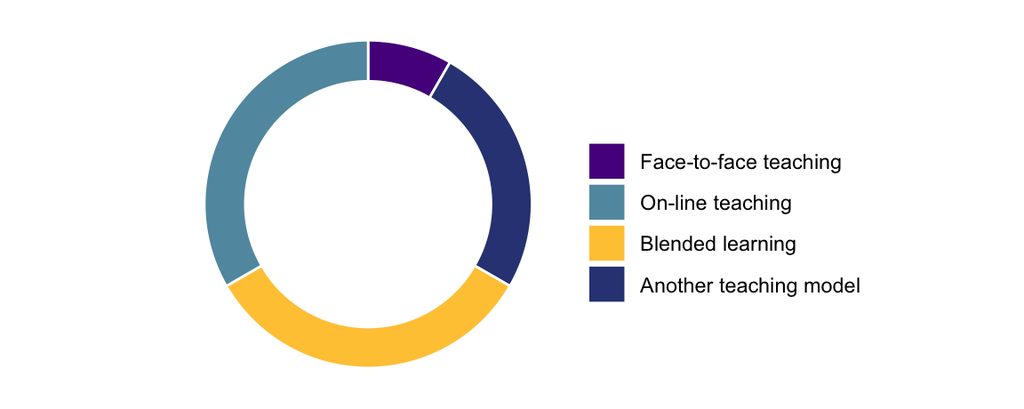

The following diagram illustrates the timeframe during which nurses are expected to complete the 20-hour GRN course.

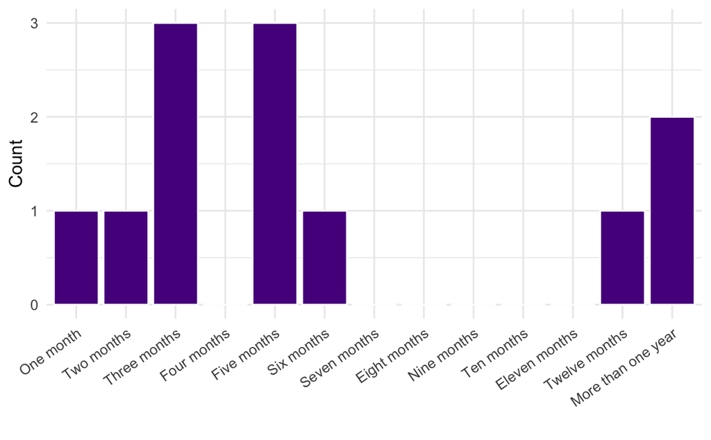

The following diagram illustrates the total release time allocated for staff to complete the GRN course at the organizations in this LTP Cohort.

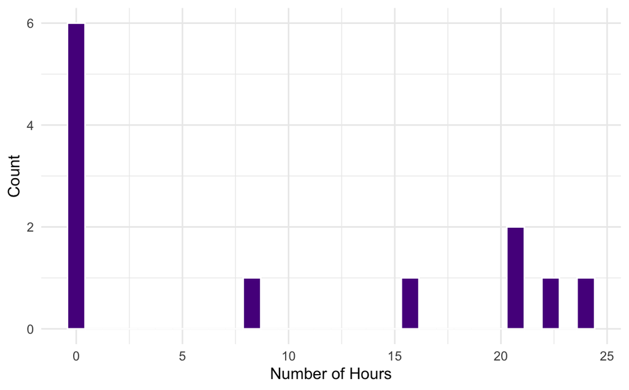

The following diagram illustrates the total number of geriatric-specific continuing training hours that GRNs are required to complete each year at the organizations in this LTP Cohort.

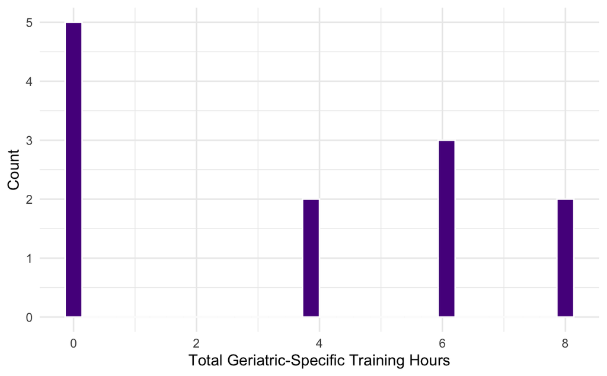

## Clinical Improvement and Practice Change Initiatives in Geriatric Care

The following diagram illustrates the clinical problems that are the foci for quality improvement and practice change projects on the NICHE nursing units at the organizations in this LTP Cohort.

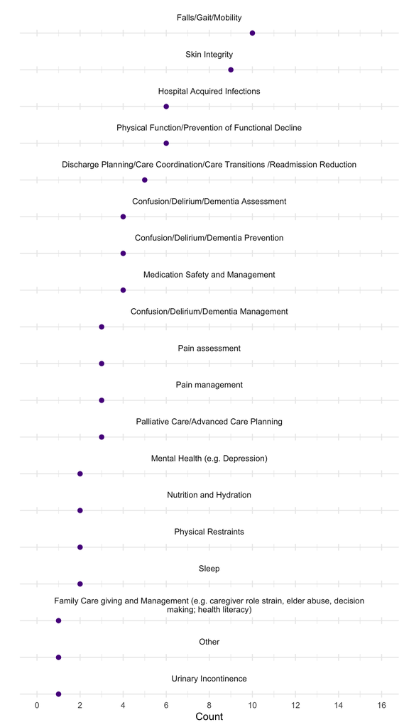

The following diagram illustrates the percent of organizations in this LTP Cohort that are implementing an Acute Care for Elders (ACE) Unit as part of their NICHE program.

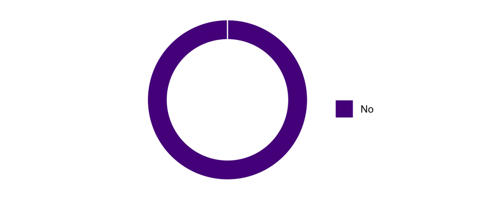

The following diagram illustrates evidence-based Geriatric Care Models that are implemented at the organizations in this LTP Cohort in addition to the NICHE model.

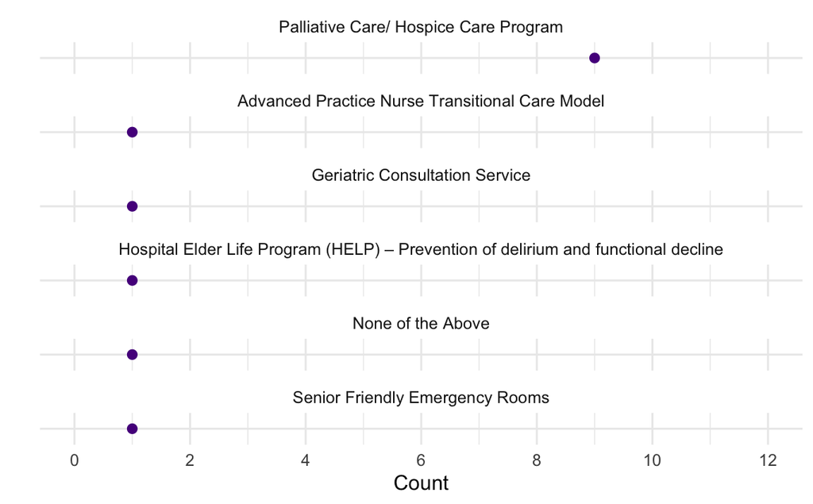

## Implementation Stages

The following charts represent this cohort’s overall performance implementing the different dimensions of the NICHE program. Dimension criteria are based on the NICHE Levels of Implementation table that can be found in the Knowledge Center.

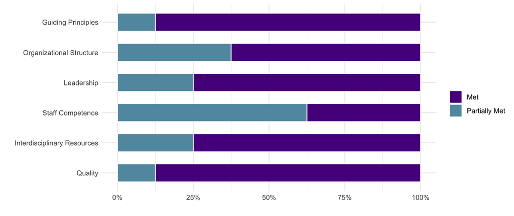

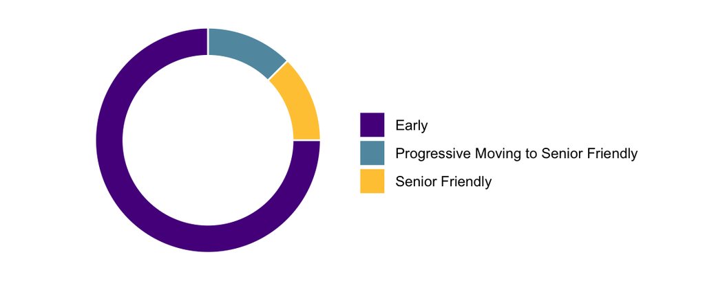